# Analysis of Variance: Two-Way ANOVA

In a two-way factorial ANOVA, subjects are assigned to groups that are formed from the cross-classification of two factors.

# 1 ANOVA F-Test vs. Regression T-Test

```r
library(datarium)
# Load the data
data("genderweight", package = "datarium")
dim(genderweight)
```

```
## [1] 40  3
```

```r
head(genderweight)
```

```
##   id group   weight
## 1  1     F 61.58587
## 2  2     F 64.55486
## 3  3     F 66.16888
## 4  4     F 59.30860
## 5  5     F 64.85825
## 6  6     F 65.01211
```

```r
table(genderweight$group)
```

```
##
##  F  M
## 20 20
```

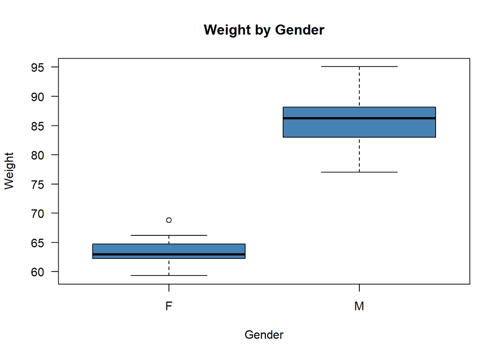

```r
boxplot(weight ~ group,
        data = genderweight,
        main = "Weight by Gender",
        xlab = "Gender",
        ylab = "Weight",
        col = "steelblue",
        border = "black",
        las = 1)
```

```r
aggregate(genderweight$weight, by=list(genderweight$group), FUN=mean)
```

```
##   Group.1        x
## 1       F 63.49867
## 2       M 85.82612
```

```r
aggregate(genderweight$weight, by=list(genderweight$group), FUN=sd)
```

```
##   Group.1        x
## 1       F 2.027615
## 2       M 4.353520
```

One-Way ANOVA

```r
fit.anova <- aov(weight ~ group,data = genderweight)
summary(fit.anova)
```

```
##             Df Sum Sq Mean Sq F value Pr(>F)
## group        1   4985    4985   432.3 <2e-16 ***
## Residuals   38    438      12
## ---
## Signif. codes:  0 '***' 0.001 '**' 0.01 '*' 0.05 '.' 0.1 ' ' 1
```

```r
TukeyHSD(fit.anova)
```

```
##   Tukey multiple comparisons of means
##     95% family-wise confidence level
##
## Fit: aov(formula = weight ~ group, data = genderweight)
##
## $group
##         diff      lwr     upr p adj
## M-F 22.32744 20.15349 24.5014     0
```

Linear Regression T-Test

```r
fit.lm <- lm(weight ~ group,data = genderweight)
summary(fit.lm)
```

```
##
## Call:
## lm(formula = weight ~ group, data = genderweight)
##
## Residuals:
##     Min      1Q  Median      3Q     Max
## -8.8163 -1.3647 -0.4869  1.3980  9.2365
##
## Coefficients:
##             Estimate Std. Error t value Pr(>|t|)
## (Intercept)  63.4987     0.7593   83.62   <2e-16 ***
## groupM       22.3274     1.0739   20.79   <2e-16 ***
## ---
## Signif. codes:  0 '***' 0.001 '**' 0.01 '*' 0.05 '.' 0.1 ' ' 1
##
## Residual standard error: 3.396 on 38 degrees of freedom
## Multiple R-squared:  0.9192, Adjusted R-squared:  0.9171
## F-statistic: 432.3 on 1 and 38 DF,  p-value: < 2.2e-16
```

# 2 Weight Loss Example

## 2.1 Weight Loss Data

Suppose we want to determine if exercise intensity and gender impact weight loss. In this case, the two factors we’re studying are `exercise` and `gender` and the response variable is `weight loss`, measured in pounds.

We can conduct a two-way ANOVA to determine if exercise and gender impact weight loss and to determine if there is an interaction between exercise and gender on weight loss.

We recruit 30 men and 30 women to participate in an experiment in which we randomly assign 10 of each to follow a program of either no exercise, light exercise, or intense exercise for one month.

The following code creates the data frame we’ll be working with:

```r
#make this example reproducible
set.seed(10)
#create data frame
data.weight <- data.frame(gender = rep(c("Male", "Female"), each = 30),
                          exercise = rep(c("None", "Light", "Intense"), each = 10, times = 2),
                          weight_loss = c(runif(10, -3, 3), runif(10, 0, 5), runif(10, 5, 9),
                                          runif(10, -4, 2), runif(10, 0, 3), runif(10, 3, 8)))
#view first six rows of data frame
head(data.weight)
```

```
##   gender exercise weight_loss
## 1   Male     None  0.04486922
## 2   Male     None -1.15938896
## 3   Male     None -0.43855400
## 4   Male     None  1.15861249
## 5   Male     None -2.48918419
## 6   Male     None -1.64738030
```

```r
#see how many participants are in each group
table(data.weight$gender, data.weight$exercise)
```

```
##
##          Intense Light None
##   Female      10    10   10
##   Male        10    10   10
```

## 2.2 Exploring the Data

Before we even fit the two-way ANOVA model, we can gain a better understanding of the data by finding the mean and standard deviation of weight loss for each of the six treatment groups.

```r
aggregate(data.weight$weight_loss, by=list(data.weight$gender, data.weight$exercise), FUN=mean)
```

```
##   Group.1 Group.2          x
## 1  Female Intense  5.3082883
## 2    Male Intense  7.3711181
## 3  Female   Light  0.9199321
## 4    Male   Light  2.1333465
## 5  Female    None -0.5008248
## 6    Male    None -0.6977007
```

```r
aggregate(data.weight$weight_loss, by=list(data.weight$gender, data.weight$exercise), FUN=sd)
```

```
##   Group.1 Group.2         x
## 1  Female Intense 1.0235052
## 2    Male Intense 0.9282676
## 3  Female   Light 0.8352550
## 4    Male   Light 1.2216122
## 5  Female    None 1.7653246
## 6    Male    None 1.1195500
```

We can also create a boxplot for each of the six treatment groups to visualize the distribution of weight loss for each group:

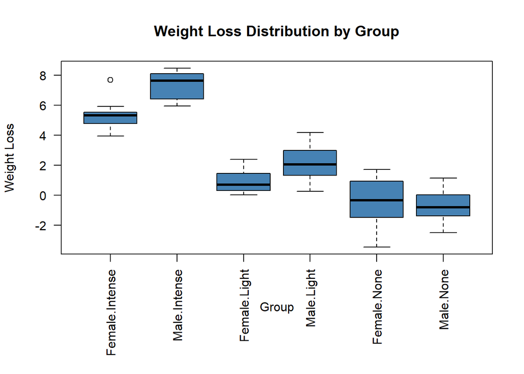

```r
#set margins so that axis labels on boxplot don't get cut off
par(mar=c(8, 4.1, 4.1, 2.1))

#create boxplots
boxplot(weight_loss ~ gender:exercise,
data = data.weight,
main = "Weight Loss Distribution by Group",
xlab = "Group",
ylab = "Weight Loss",
col = "steelblue",
border = "black",
las = 2 #make x-axis labels perpendicular
)
```

- Right away we can see that the two groups who participated in intense exercise appear to have greater weight loss values.
- We can also see that males tend to have higher weight loss values for the intense and light exercise groups compared to females.

## 2.3 Fitting the Two-Way ANOVA Model

Next, we’ll fit the two-way ANOVA model to our data to see if these visual differences are actually statistically significant.

```r
#fit the two-way ANOVA model
model <- aov(weight_loss ~ gender * exercise, data = data.weight)
#view the model output
summary(model)
```

```
##                 Df Sum Sq Mean Sq F value Pr(>F)
## gender           1   15.8   15.80  11.197 0.0015 **
## exercise         2  505.6  252.78 179.087 <2e-16 ***
## gender:exercise  2   13.0    6.51   4.615 0.0141 *
## Residuals       54   76.2    1.41
## ---
## Signif. codes:  0 '***' 0.001 '**' 0.01 '*' 0.05 '.' 0.1 ' ' 1
```

From the model output we can see that `gender`, `exercise`, and the interaction between the two variables are all statistically significant at the .05 significance level.

## 2.4 Checking the Model Assumptions

Before we go any further, we should check to see that the assumptions of our model are met so that the our results from the model are reliable. In particular, a two-way ANOVA assumes:

**1. Independence** - the observations in each group need to be independent of each other. Since we used a randomized design, this assumption should be met so we don’t need to worry too much about this.

**2. Normality** - the dependent variable should be approximately normally distributed for each combination of the groups of the two factors.

One way to check this assumption is to create a histogram of the model residuals. If the residuals are roughly normally distributed, this assumption should be met.

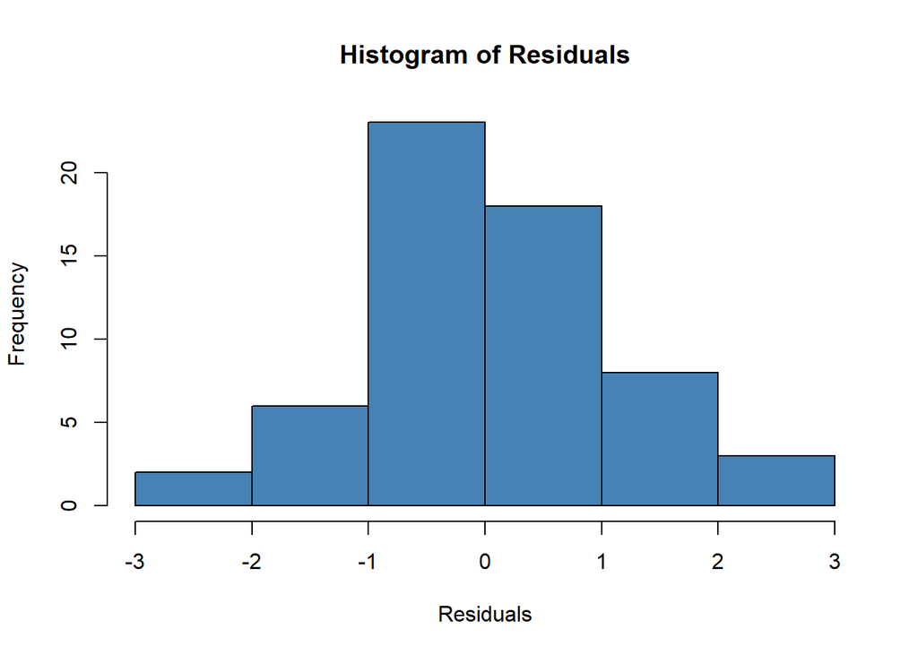

```r
#define model residuals
resid <- model$residuals
#create histogram of residuals
hist(resid, main = "Histogram of Residuals", xlab = "Residuals", col = "steelblue")
```

The residuals are roughly normally distributed, so we can assume the normality assumption is met.

**3. Equal Variance** - the variances for each group are equal or approximately equal.

One way to check this assumption is to conduct a Levene’s Test for equality of variances using the **car** package:

```r
#load car package
library(car)
#conduct Levene's Test for equality of variances
leveneTest(weight_loss ~ gender * exercise, data = data.weight)
```

```
## Levene's Test for Homogeneity of Variance (center = median)
##       Df F value Pr(>F)
## group  5  1.8547 0.1177
##       54
```

Since the p-value of the test is greater than our significance level of 0.05, we can assume that our assumption of equality of variances among groups is met.

## 2.5 Analyzing Treatment Differences

Once we have verified that the model assumptions are met, we will use the function `TukeyHSD()` to conduct Tukey’s Test for multiple comparisons:

```r
#perform Tukey's Test for multiple comparisons
TukeyHSD(model, conf.level=.95)
```

```
##   Tukey multiple comparisons of means
##     95% family-wise confidence level
##
## Fit: aov(formula = weight_loss ~ gender * exercise, data = data.weight)
##
## $gender
##                 diff       lwr      upr     p adj
## Male-Female 1.026456 0.4114451 1.641467 0.0014967
##
## $exercise
##                    diff       lwr       upr   p adj
## Light-Intense -4.813064 -5.718493 -3.907635 0.0e+00
## None-Intense  -6.938966 -7.844395 -6.033537 0.0e+00
## None-Light    -2.125902 -3.031331 -1.220473 1.8e-06
##
## $`gender:exercise`
##                                   diff        lwr         upr     p adj
## Male:Intense-Female:Intense  2.0628297  0.4930588  3.63260067 0.0036746
## Female:Light-Female:Intense -4.3883563 -5.9581272 -2.81858535 0.0000000
## Male:Light-Female:Intense   -3.1749419 -4.7447128 -1.60517092 0.0000027
## Female:None-Female:Intense  -5.8091131 -7.3788841 -4.23934219 0.0000000
## Male:None-Female:Intense    -6.0059891 -7.5757600 -4.43621813 0.0000000
## Female:Light-Male:Intense   -6.4511860 -8.0209570 -4.88141508 0.0000000
## Male:Light-Male:Intense     -5.2377716 -6.8075425 -3.66800066 0.0000000
## Female:None-Male:Intense    -7.8719429 -9.4417138 -6.30217192 0.0000000
## Male:None-Male:Intense      -8.0688188 -9.6385897 -6.49904786 0.0000000
## Male:Light-Female:Light      1.2134144 -0.3563565  2.78318536 0.2185439
## Female:None-Female:Light    -1.4207568 -2.9905278  0.14901410 0.0974193
## Male:None-Female:Light      -1.6176328 -3.1874037 -0.04786184 0.0398106
## Female:None-Male:Light      -2.6341713 -4.2039422 -1.06440032 0.0001050
## Male:None-Male:Light        -2.8310472 -4.4008181 -1.26127627 0.0000284
## Male:None-Female:None       -0.1968759 -1.7666469  1.37289500 0.9990364
```

The p-value indicates whether or not there is a statistically significant difference between each group.

We can also visualize the 95% confidence intervals that result from the Tukey Test by using the `plot()` function in R:

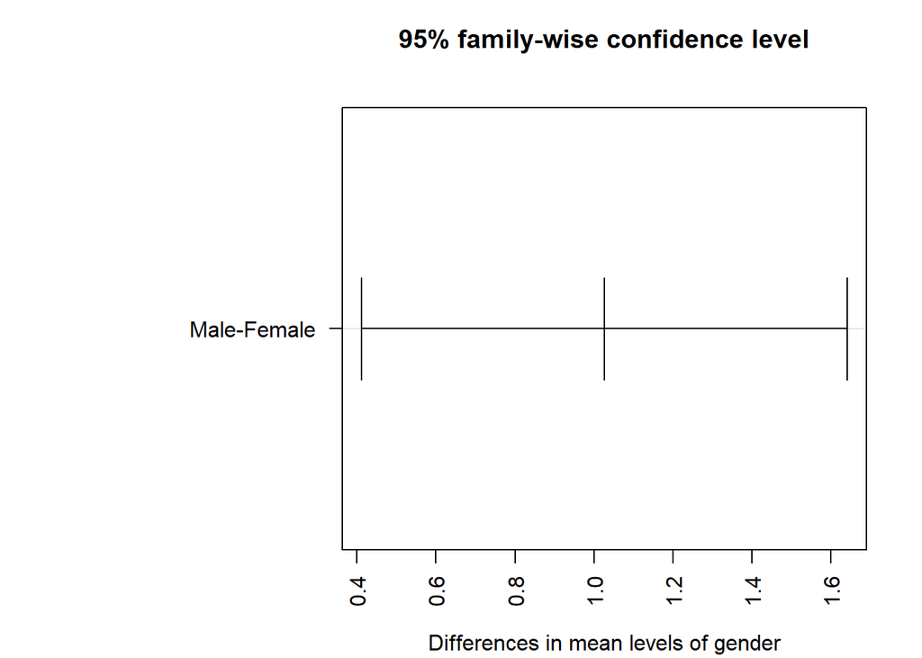

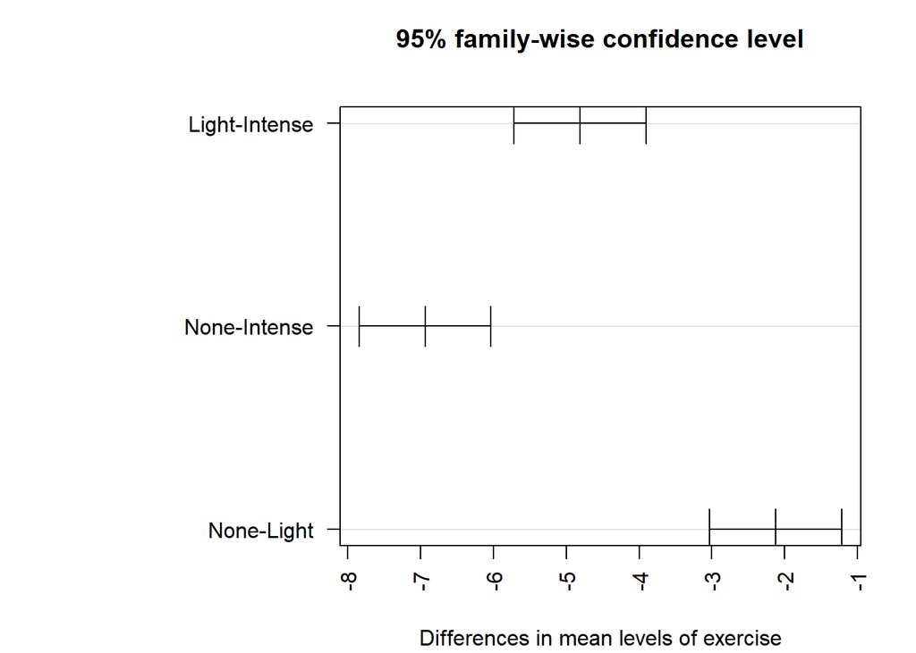

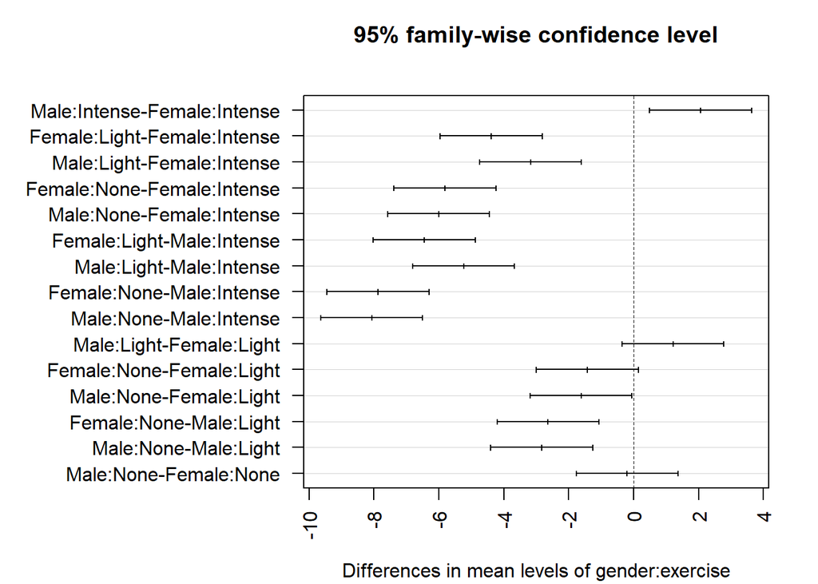

```r
#set axis margins so labels don't get cut off
par(mar=c(4.1, 13, 4.1, 2.1))
#create confidence interval for each comparison
plot(TukeyHSD(model, conf.level=.95), las = 2)
```

## 2.6 Reporting the Results of the Two-Way ANOVA

Lastly, we can report the results of the two-way ANOVA in such a way that summarizes the findings:

- A two-way ANOVA was conducted to examine the effects of gender (male, female) and exercise regimen (none, light, intense) on weight loss (measure in lbs). There was a statistically significant interaction between the effects of gender and exercise on weight loss (F(2, 54) = 4.615, p = 0.0141). Tukey’s HSD post hoc tests were carried out.
- For males, an intense exercise regimen lead to significantly higher weight loss compared to both a light regimen (p < .0001) and no exercise regimen (p < .0001). In addition for males, a light regimen lead to significantly higher weight loss compared to no exercise regimen (p < .0001).
- For females, an intense exercise regimen lead to significantly higher weight loss compared to both a light regimen (p < .0001) and no exercise regimen (p < .0001).
- Normality checks and Levene’s test were conducted to verify that the ANOVA assumptions were met.

# 3 ToothGrowth Example

## 3.1 ToothGrowth Data

We uses the `ToothGrowth` dataset in the base installation to demonstrate a two-way between-groups ANOVA. Sixty guinea pigs are randomly assigned to receive

- one of three levels of ascorbic acid (0.5, 1, or 2mg).
- one of two delivery methods (orange juice or Vitamin C).
- under the restriction that each treatment combination has 10 guinea pigs.
- The dependent variable is tooth length.

```r
attach(ToothGrowth)
dim(ToothGrowth)
```

```
## [1] 60  3
```

```r
head(ToothGrowth)
```

```
##    len supp dose
## 1  4.2   VC  0.5
## 2 11.5   VC  0.5
## 3  7.3   VC  0.5
## 4  5.8   VC  0.5
## 5  6.4   VC  0.5
## 6 10.0   VC  0.5
```

```r
table(supp,dose)
```

```
##     dose
## supp 0.5  1  2
##   OJ  10 10 10
##   VC  10 10 10
```

```r
# The design is balanced, so you don't have to worry about the order of effects.
```

## 3.2 Exploring the Data

```r
aggregate(len, by=list(supp, dose), FUN=mean)
```

```
##   Group.1 Group.2     x
## 1      OJ     0.5 13.23
## 2      VC     0.5  7.98
## 3      OJ     1.0 22.70
## 4      VC     1.0 16.77
## 5      OJ     2.0 26.06
## 6      VC     2.0 26.14
```

```r
aggregate(len, by=list(supp, dose), FUN=sd)
```

```
##   Group.1 Group.2        x
## 1      OJ     0.5 4.459709
## 2      VC     0.5 2.746634
## 3      OJ     1.0 3.910953
## 4      VC     1.0 2.515309
## 5      OJ     2.0 2.655058
## 6      VC     2.0 4.797731
```

We can create a boxplot for each of the six treatment groups to visualize the distribution of length of tooth growth for each group:

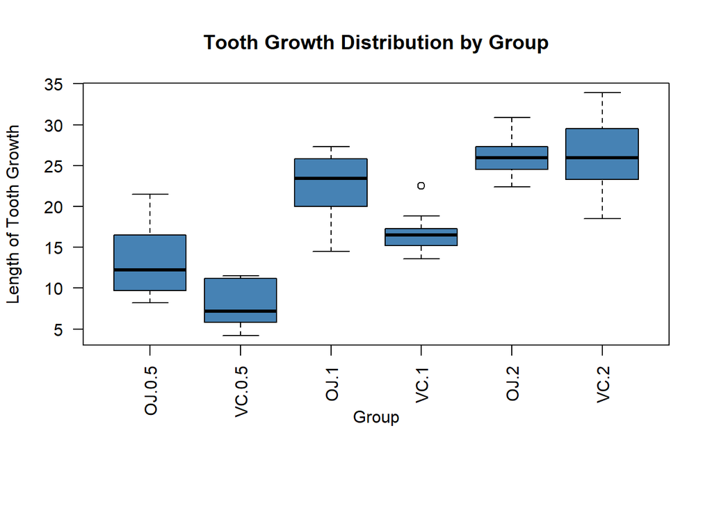

```r
#set margins so that axis labels on boxplot don't get cut off
par(mar=c(8, 4.1, 4.1, 2.1))

#create boxplots
boxplot(len ~ supp:dose,
data = ToothGrowth,
main = "Tooth Growth Distribution by Group",
xlab = "Group",
ylab = "Length of Tooth Growth",
col = "steelblue",
border = "black",
las = 2 #make x-axis labels perpendicular
)
```

## 3.3 Fitting the Two-Way ANOVA Model

### 3.3.1 Two-Way ANOVA Model Without Interaction

```r
fit_twoway <- aov(len ~ supp+dose)
summary(fit_twoway)
```

```
##             Df Sum Sq Mean Sq F value   Pr(>F)
## supp         1  205.4   205.4   11.45   0.0013 **
## dose         1 2224.3  2224.3  123.99 6.31e-16 ***
## Residuals   57 1022.6    17.9
## ---
## Signif. codes:  0 '***' 0.001 '**' 0.01 '*' 0.05 '.' 0.1 ' ' 1
```

The ANOVA table provided by the `summary()` function indicates that main effects (`supp` and `dose`) are significant.

### 3.3.2 Two-Way ANOVA Model With Interaction

```r
fit_twoway_interaction <- aov(len ~ supp*dose)
summary(fit_twoway_interaction)
```

```
##             Df Sum Sq Mean Sq F value   Pr(>F)
## supp         1  205.4   205.4  12.317 0.000894 ***
## dose         1 2224.3  2224.3 133.415  < 2e-16 ***
## supp:dose    1   88.9    88.9   5.333 0.024631 *
## Residuals   56  933.6    16.7
## ---
## Signif. codes:  0 '***' 0.001 '**' 0.01 '*' 0.05 '.' 0.1 ' ' 1
```

The ANOVA table provided by the `summary()` function indicates that both main effects (`supp` and `dose`) and the interaction between these factors are significant.

**Figure 1**. Interaction between dose and delivery mechanism on tooth growth. The plot of means was created using the `interaction.plot()` function.

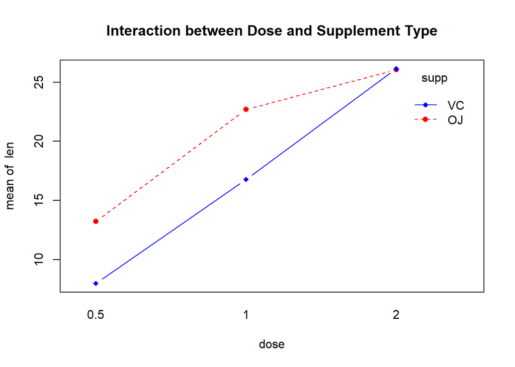

```r
interaction.plot(dose, supp, len, type="b",
                 col=c("red","blue"), pch=c(16, 18),
                 main = "Interaction between Dose and Supplement Type")
```

The plot provides the mean tooth length for each supplement at each dosage.

1. All three graphs indicate that tooth growth increases with the dose of ascorbic acid for both orange juice and Vitamin C.
2. For the 0.5 and 1mg doses, orange juice produced more tooth growth than Vitamin C.
3. For 2mg of ascorbic acid, both delivery methods produced identical growth.

**Figure 2**. Interaction between dose and delivery mechanism on tooth growth. The mean plot with 95 percent confidence intervals was created by the `plotmeans()` function.

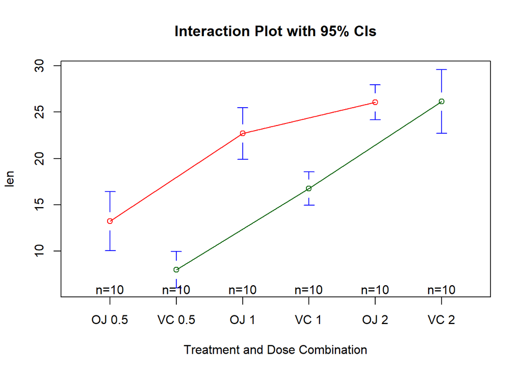

```r
library(gplots)
plotmeans(len ~ interaction(supp, dose, sep=" "),
          connect=list(c(1,3,5),c(2,4,6)),
          col=c("red", "darkgreen"),
          main = "Interaction Plot with 95% CIs",
          xlab="Treatment and Dose Combination")
```

The graph includes the means, as well as error bars (95 percent confidence intervals) and sample sizes.

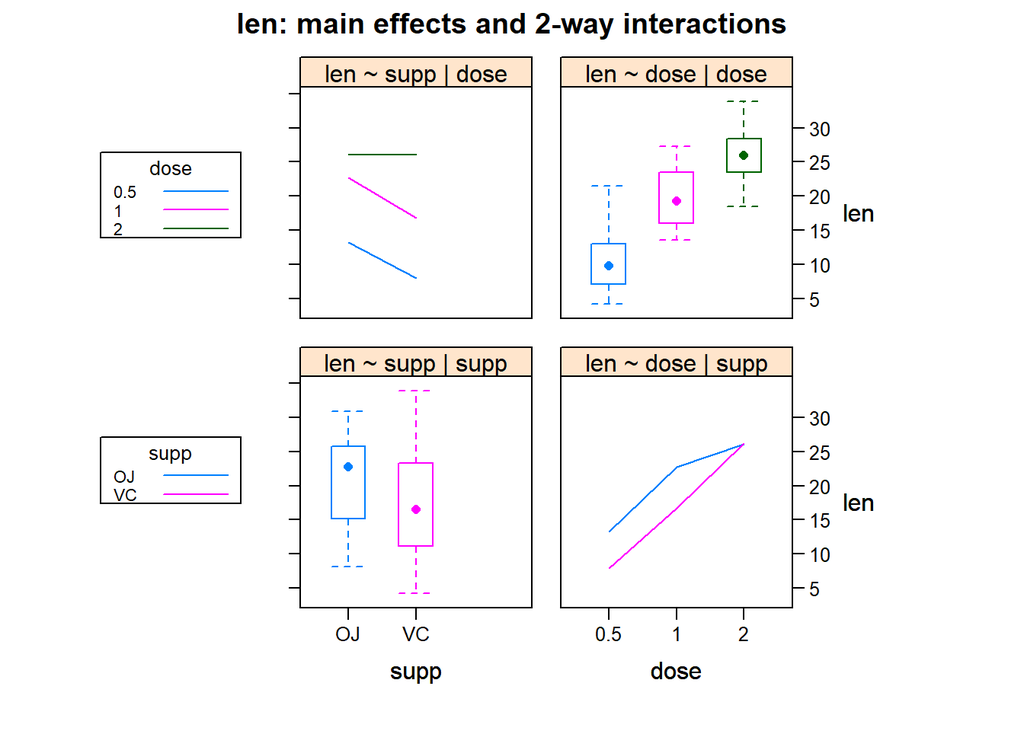

```r
library(HH)
interaction2wt(len~supp*dose)
```

You can use the `interaction2wt()` function in the `HH` package to produce a plot of both main effects and two-way interactions for any factorial design of any order.